# Small example of ATE estimation with missing attributes

Imke Mayer

# 1 Introduction

The objective of this notebook is to illustrate how to perform treatment effect estimation with missing attributes on a small toy example. By replacing the toy example with the dataset of your choice (following the format instructions below) you can estimate average treatment effects (ATE) on your own data.

For more information and details on the theoretical background of the methodology, we refer to [(Mayer et al. 2020)](http://dx.doi.org/10.1214/20-AOAS1356).

**You can replace the chunks `rename_data` and `confounders` with any data set you wish to analyze. For this, you have to specify:**

- `X.na`: confounders. A data.frame of size `#observations x #covariates`. With or without missing values.
- `W`: treatment assignment. A binary vector coded either with `{0,1}` or with `{FALSE,TRUE}` (representing `{control,treatment}`). Without missing values.
- `Y`: observed outcome. A numerical or binary vector (if binary, then coded with `{0,1}`). Without missing values.

And at the end of the chunk `rename_data`, set `synthetic=FALSE`, if you choose your own data set.

If `X.na` contains confounders but also other covariates that are not to be considered as confounders in the analysis, specify the names of the confounders in the chunk `confounders` and the role of the remaining covariates (either treatment regressors or outcome regressors).

# 2 Preliminaries

## 2.1 Load libraries

```r
library(cobalt)
library(ggplot2)
library(dplyr)
library(MASS)
library(pracma)
library(assertthat)

library(caret) #
library(ranger) # Random Forests prediction
library(FactoMineR) # Factorial data analysis
library(grf) # Doubly robust treatment effect estimation

library(norm)
library(missMDA) # PCA/MCA with missing values + iterative PC imputation
library(mice) # Multiple imputation
library(VIM) # Missing values exploration and visualization

library(devtools)
# Load the ATE estimation functions `ipw` and `dr` from the GitHub repository
source_url("https://raw.githubusercontent.com/imkemayer/causal-inference-missing/master/Helper/helper_causalInference.R")
# Load function to generate missing values using different mechanisms from R-miss-tastic
source_url("https://rmisstastic.netlify.app/how-to/generate/amputation.R")

# Set random generator seed for reproducible results
set.seed(1234)
```

## 2.2 Generate toy example

We will generate a simple toy data set with normally distributed confounders and MCAR missing values. For generating missing values, we use code provided by [(Mayer et al. 2019)](https://arxiv.org/abs/1908.04822).

```r
seed <- 4321
n <- 5000
p <- 5
tau <- 1
```

```r
rho <- 0.3
Sigma <- diag(p) + rho*upper.tri(diag(p)) + rho*lower.tri(diag(p))
X <- mvrnorm(n=n, mu=rep(1, p), Sigma=Sigma)
res.na <- produce_NA(X, mechanism="MCAR", perc.missing=0.3, seed=seed)
X.na <- res.na$data.incomp

# nonlinear transformations of X
X.tmp <- X
for (j in 1:p){
  X.tmp[,j] <- (mod(j,5)==1)*((X.tmp[,j]<quantile(X.tmp[,j],0.7)) + (X.tmp[,j]> quantile(X.tmp[,j],0.2))) +
               (mod(j,5)==2)*(1/(0.001+exp(X.tmp[,j]*X.tmp[,1]))) +
               (mod(j,5)==3)*(-(X.tmp[,j])*(X.tmp[,2]>0)) +
               (mod(j,5)==4)*(-2.5*sqrt(abs(X.tmp[,j]))) +
               (mod(j,5)==0)*(X.tmp[,3]*X.tmp[,j])
}

# propensity scores
X.tmp.ps <- X.tmp
X.tmp.ps[res.na$idx_newNA] <- 0
expit <- function(x){ return(1/(1+exp(-x))) }
alpha <- array(c(-0.6, 0.6), dim=p)
prop_scores <- apply(data.frame(X.tmp), MARGIN=1,
                          FUN=function(z) expit(z%*%alpha))
prop_scores <- 0.01 + (pmin(0.98,prop_scores) - min(prop_scores))/(max(prop_scores)-min(prop_scores))
W <- sapply(prop_scores, FUN=function(p) rbinom(n=1, size=1, prob=p))


# outcome
epsilons <- rnorm(n, sd=0.2)
Y <- rep(0,n)
beta <- runif(p, -1, 1)

Y[which(W==1)] <- sign(X.tmp[which(W==1),]%*%beta)*log(abs(X.tmp[which(W==1),]%*%beta)) + tau + epsilons[which(W==1)]
Y[which(!(W==1))] <- sign(X.tmp[which(!(W==1)),]%*%beta)*log(abs(X.tmp[which(!(W==1)),]%*%beta)) + epsilons[which(!(W==1))]

toy_data <- list(X=X, X.na=X.na, W=W, Y=Y)
```

**If you want to use your own data set, change the following chunk, following the instructions given in the introduction.**

```r
synthetic <- TRUE

X.na <- data.frame(toy_data$X.na)
W <- toy_data$W
Y <- toy_data$Y

covariate_names <- colnames(X.na)
n <- dim(X.na)[1]
p <- dim(X.na)[2]

df.na <- data.frame(cbind(X.na, W=W, Y=Y))
colnames(df.na) <- c(covariate_names, "W", "Y")
```

In certain cases, not all covariates are necessarily confounders. Therefore we specify the set of confounders (here we consider all covariates to be confounders). Additionally, in some cases there are also variables that are only predictive of the treatment assignment. Their names can be specified in `only_treatment_pred_names`.

```r
confounder_names <- covariate_names
only_treatment_pred_names <- c()
only_outcome_pred_names <- setdiff(covariate_names,
                                   c(confounder_names, only_treatment_pred_names))
```

First we compute the unadjusted ATE, ignoring the confounders.

```r
ate_raw <- mean(Y[which(as.logical(W))]) - mean(Y[which(!as.logical(W))])
```

This gives us $ATE_{naive}=$ 1.0758018.

Let us also assess how the outcome is distributed with respect to the treatment group.

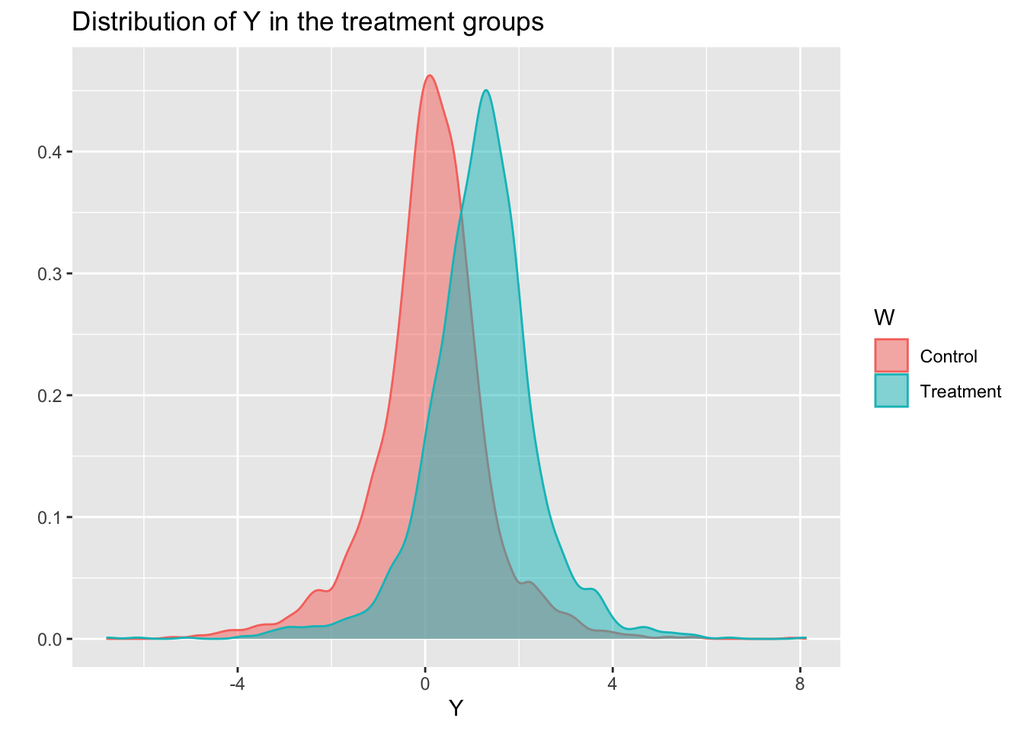

From these two variables, $W$ and $Y$, we can compute the following descriptive statistics:

- Average outcome: $\mathbb{E}[Y]\approx$ 0.57
- $Pr(Treatment=1)\approx$ 0.424
- $\mathbb{E}[(Y \,\mid\, Treatment=1)]\approx$ 1.1876737
- $\mathbb{E}[(Y \,\mid\, Treatment=0)]\approx$ 0.1118718

# 3 Imputation

Before choosing an imputation method, it is important to explore the data and to take a look at the missing values which might exhibit certain patterns. See the appendix for an example of how to graphically examine the missing values.

We will impute the data with two different methods, iterative PCA and mice.

Note that we use both the outcome variable and the treatment assignment in the imputation model as recommended by [(Seaman and White 2014)](https://doi.org/10.1080/03610926.2012.700371).

## 3.1 Via principal components

We now perform a **single** imputation with a (regularized) iterative PCA model, which will allow imputation to take into account similarities between both individuals and relationships between variables. For more details, see [(Lê, Josse, and Husson 2008)](https://doi.org/10.18637/jss.v025.i01).

First we find the optimal number of dimensions for the imputation method by cross-validation.

**Note that if your data `X.na` contains only qualitative variables (i.e., categorical data), replace `estim_ncpFAMD` with `estim_ncpMCA`.**

```r
ncomp <- estim_ncpFAMD(data.frame(X.na, W = as.factor(W), Y = Y),
                        ncp.min = 1,
                        ncp.max=p,
                        method= "Regularized",
                        method.cv = "Kfold",
                        nbsim=10,
                        verbose = TRUE)

plot(1:length(ncomp$criterion), ncomp$criterion, xlab = "nb dim", ylab = "MSEP")
```

On this toy example, we do not run the above chunk to speed up the calculations. We will arbitrarily set `ncp=3`.

**Same as for the `ncomp_all` chunk, replace `imputeFAMD` with `imputeMCA`.**

```r
ncp <- 3
df.tmp <- data.frame(X.na, W = as.factor(W), Y = Y)
colnames(df.tmp) <- colnames(df.na)
df.imp.pc <- data.frame(imputeFAMD(df.tmp, ncp=ncp, seed=seed)$completeObs)
levels(df.imp.pc$W) <- c(0,1)
df.imp.pc$W <- as.numeric(as.character(df.imp.pc$W))
```

## 3.2 MICE

We also do a **multiple** imputation analysis, using the `mice` package. We impute the data `m=5` times.

```r
m <- 5
df.imp.mice <- mice(df.na, m=m, seed=seed, printFlag=F)
```

# 4 ATE estimation

The analyses that follow illustrate how to estimate the ATE. There exist however other similar estimands that differ slightly from the ATE but might be more relevant in certain applications You can produce estimates for these different estimands by changing the variable `target` in the chunk `choose_target` below to

- `target="treated"` for the ATT
- `target ="control"` for the ATC
- `target=,"overlap"` for the ATE with overlap weights

```r
target <- "all"
```

We estimate the ATE with two different estimators and two possibilities to estimate nuisance parameters (i.e., the propensity scores and the conditional response surfaces). A classical choice for nuisance parameter estimation in causal inference applications is the use of generalized linear models (in practice, mostly linear and logistic models), which we will use the `glm` function for. And more recently, more complex and flexible models became available, such as generalized regression forest [(Athey, Tibshirani, and Wager 2019)](https://doi.org/10.1214/18-AOS1709).

```r
treatment_effect_estimates <- function(data, target="all",
                                       confounder_names=NULL,
                                       only_treatment_pred_names=NULL,
                                       only_outcome_pred_names=NULL,
                                       seed=NULL) {
  if (is.null(confounder_names)) {
    confounder_names <- setdiff(colnames(data), c("W","Y"))
  }

  results <- list()
  results <- data.frame(matrix(ncol=4, nrow=0), row.names = NULL)

  if (sum(is.na(data))==0){
    tmp <- ipw(X=data[, confounder_names],
               outcome=data$Y, treat=as.logical(data$W),
               ps.method="glm", target=target,
               seed=seed)
    results <- rbind(results,
                     cbind("glm", "IPW_normalized_weights", tmp[[1]], tmp[[3]]))
    results <- rbind(results,
                     cbind("glm", "IPW_unnormalized_weights", tmp[[2]], tmp[[4]]))
  }

  tmp <- ipw(X=data[, confounder_names],
             outcome=data$Y, treat=as.logical(data$W),
             ps.method="grf", target=target,
             seed=seed)
  results <- rbind(results,
                   cbind("grf", "IPW_normalized_weights", tmp[[1]], tmp[[3]]))
  results <- rbind(results,
                   cbind("grf", "IPW_unnormalized_weights", tmp[[2]], tmp[[4]]))

  if (sum(is.na(data))==0){
    tmp <- dr(X=data[, confounder_names],
              X.for.ps = data[, c(only_treatment_pred_names,confounder_names)],
              X.for.outcome = data[, c(only_treatment_pred_names,confounder_names)],
              outcome = data$Y, treat = as.logical(data$W),
              ps.method = "glm.grf", out.method = "glm.grf",
              target = target,
              seed=seed)
    results <- rbind(results,
                     cbind("glm", "DR", tmp[[1]], tmp[[2]]))
  }
  tmp <- dr(X=data[, confounder_names],
            X.for.ps = data[, c(only_treatment_pred_names,confounder_names)],
            X.for.outcome = data[, c(only_treatment_pred_names,confounder_names)],
            outcome = data$Y, treat = as.logical(data$W),
            ps.method = "grf.ate", out.method = "grf.ate",
            target = target,
            seed=seed)
  results <- rbind(results,
                   cbind("grf", "DR", tmp[[1]], tmp[[2]]))

  colnames(results) <- c("Nuisance.estimation",
                         "Estimate",
                         "Value",
                         "StandardError")
  results$Value <- as.numeric(results$Value)
  results$StandardError <- as.numeric(results$StandardError)
  return(results)
}
```

```r
results_pc_imp <- treatment_effect_estimates(df.imp.pc, target=target,
                                             seed=seed)
```

```r
res_tmp <- complete(df.imp.mice, "all") %>% lapply(treatment_effect_estimates,target=target, seed=seed)
res_val <- as.data.frame(do.call(rbind, lapply(res_tmp, "[", , "Value")))
res_se <- as.data.frame(do.call(rbind, lapply(res_tmp, "[", , "StandardError")))
results_mice_imp <- cbind(res_tmp[[1]][,1:2],
                          apply(res_val,2, mean),
                          sapply(1:dim(res_tmp[[1]])[1],
                                 function(j) sqrt(mean(res_se[,j]^2*n)+ (1+1/m)*sum((res_val[,j]-mean(res_val[,j]))^2)/(m-1))/sqrt(n)))
colnames(results_mice_imp) <- colnames(res_tmp[[1]])
```

```r
results_mia <- treatment_effect_estimates(df.na, target=target,
                                             seed=seed)
```

# 5 Results

## 5.1 Table of all results

ATE estimations

| NA.handling | Nuisance.estimation | Estimate | Value | StandardError |
| --- | --- | --- | --- | --- |
| pc.imp | glm | IPW_normalized_weights | 1.12 | 0.06 |
| pc.imp | glm | IPW_unnormalized_weights | 1.05 | 0.05 |
| pc.imp | grf | IPW_normalized_weights | 0.99 | 0.04 |
| pc.imp | grf | IPW_unnormalized_weights | 1.04 | 0.05 |
| pc.imp | glm | DR | 1.03 | 0.04 |
| pc.imp | grf | DR | 0.98 | 0.03 |
| mice | glm | IPW_normalized_weights | 1.02 | 0.05 |
| mice | glm | IPW_unnormalized_weights | 1.00 | 0.05 |
| mice | grf | IPW_normalized_weights | 0.96 | 0.04 |
| mice | grf | IPW_unnormalized_weights | 1.00 | 0.04 |
| mice | glm | DR | 0.99 | 0.04 |
| mice | grf | DR | 0.94 | 0.03 |
| mia | grf | IPW_normalized_weights | 0.97 | 0.04 |
| mia | grf | IPW_unnormalized_weights | 1.03 | 0.04 |
| mia | grf | DR | 0.98 | 0.03 |

## 5.2 Plots

We will plot all the previously calculated results.

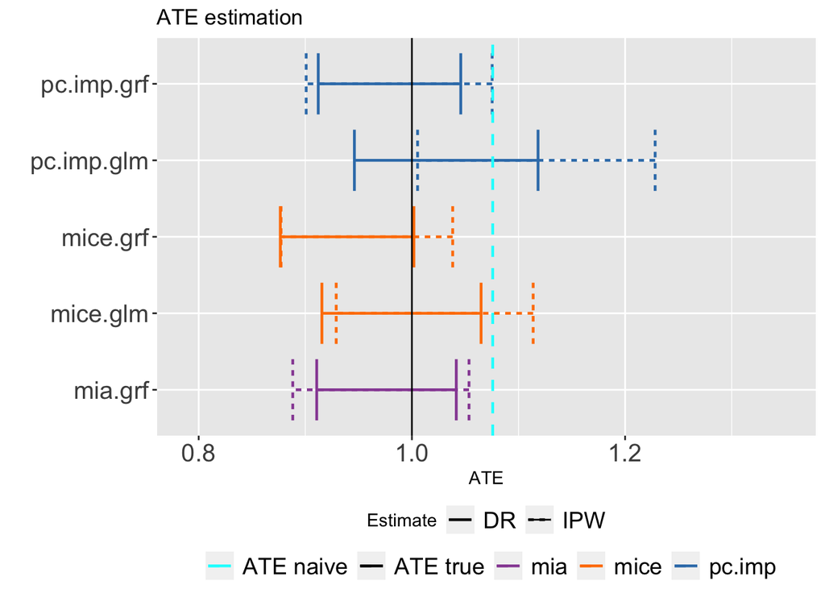

# 6 Appendix

## 6.1 Missing values visualization

In general settings, we don’t know how the missing values are generated. So let’s look at the matrix plot to identify if there are any variables that tend to be missing together or if we can detect any clear violation of the missing completely at random hypothesis:

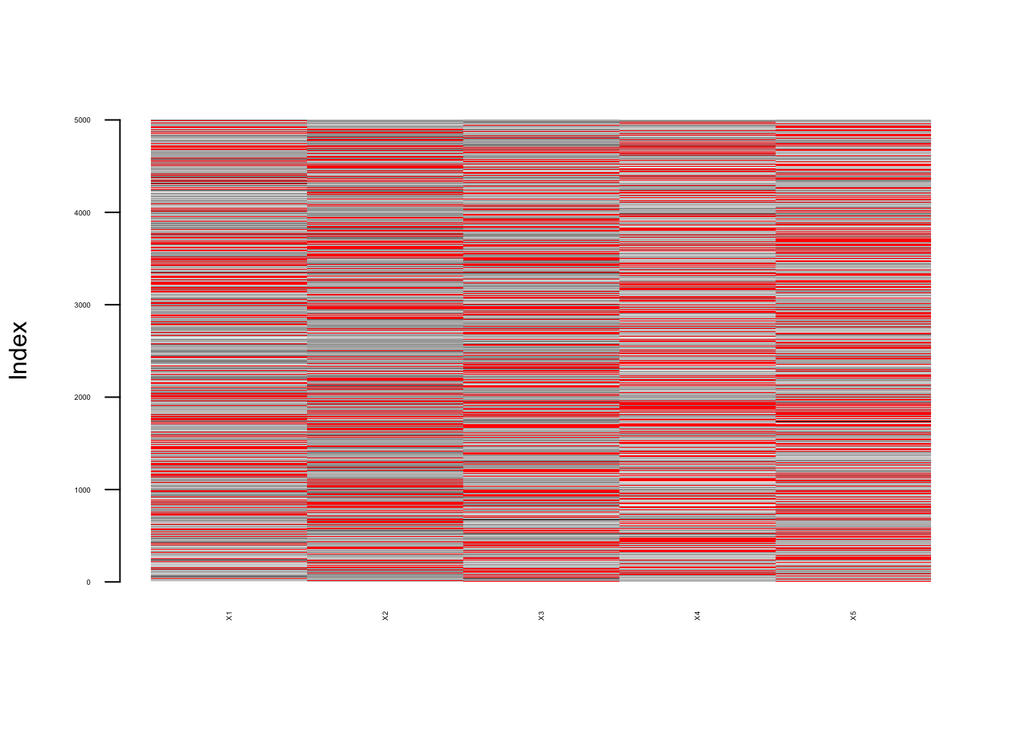

```
##
## Click in a column to sort by the corresponding variable.
## To regain use of the VIM GUI and the R console, click outside the plot region.
```

```r
matrixplot(X.na, las=2, cex.axis = 0.3)
```

We can also run MCA on the missing and non missing entries to double check our conclusion and to check if other groups of variables tend to be missing together:

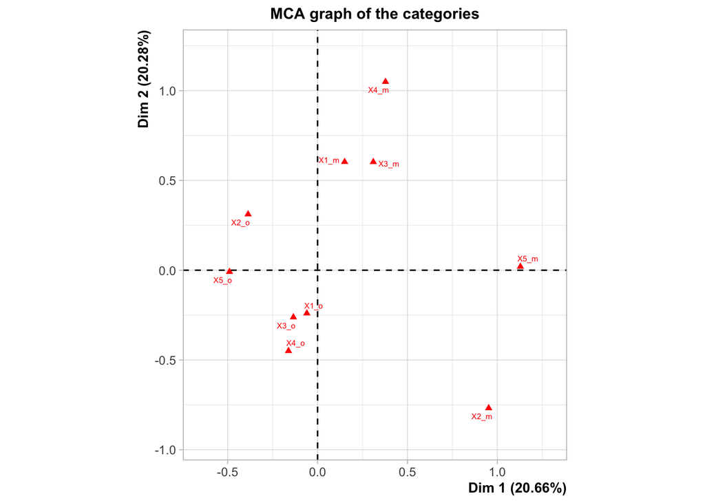

```r
data_miss <- data.frame(is.na(X.na))
data_miss <- apply(X=data_miss, FUN=function(x) if(x) "m" else "o", MARGIN=c(1,2))
res.mca <- MCA(data_miss, graph = FALSE)
plot(res.mca, invis = "ind", title = "MCA graph of the categories", cex =0.5)
```

## 6.2 Balance plots

The standardized mean differences (SMD) higher than some threshold th, for instance th=0.1, indicate that the covariate distributions in the two groups differ: the treatment is not given uniformly at random. This explains the need for some adjustment or balancing in order to perform a causal analysis of the treatment on a certain outcome.

We use propensity score estimations from the `grf` package.

### 6.2.1 On `X.imp.pc`

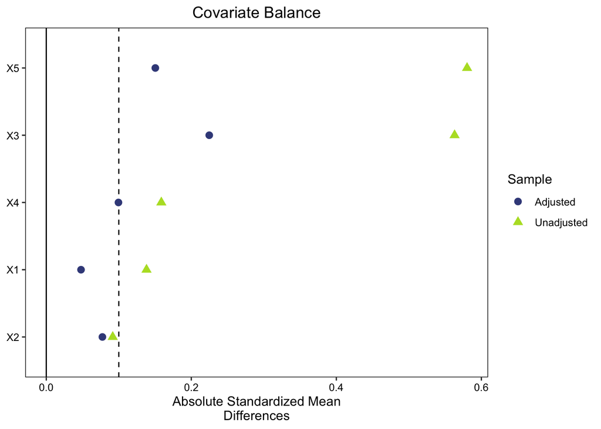

We can also use the previously computed weights to look at the balance of the response pattern.

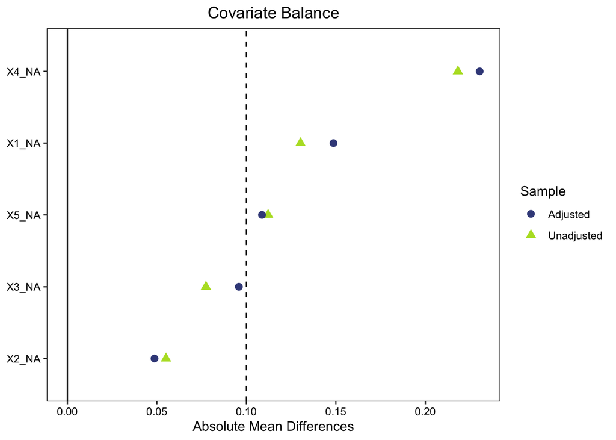

```r
incomplete_confounders <- confounder_names[which(sapply(X.na[,confounder_names], function(x) sum(is.na(x))>0))]
R <- data.frame(is.na(X.na[,incomplete_confounders]))
colnames(R) <- paste(incomplete_confounders, "_NA", sep="")
balance <- bal.tab(R, treat = W, estimand="ATE", weights = weights, method = "weighting", un=TRUE)

love.plot(x = balance, stat = "mean.diffs", abs = TRUE, var.order = "unadjusted",
          threshold = 0.1, cex=0.8, stars = "raw", shapes=c("circle", "triangle"),
          colors=c(viridis::viridis(10)[3], viridis::viridis(10)[9]))
```

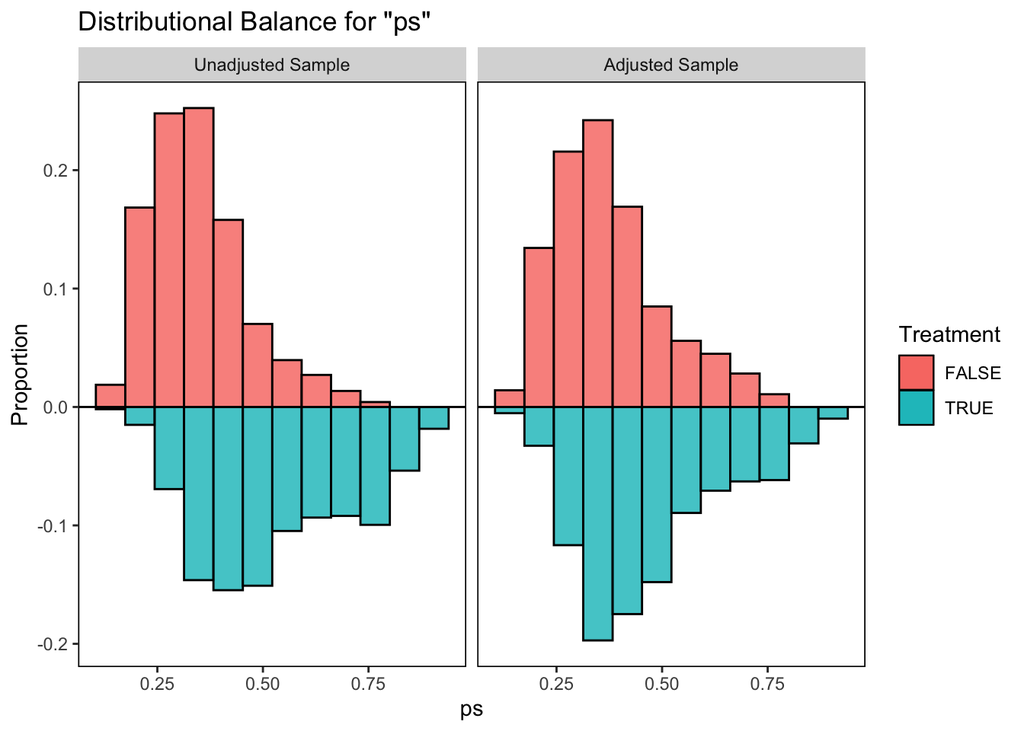

```r
bal.plot(x=data.frame(treat=as.logical(W), ps=w.hat, weights=weights), var.name = "ps", which = "both",
         treat=as.logical(W),
         weights=weights,
         type="histogram", mirror = TRUE)
```

### 6.2.2 On `X.imp.mice`

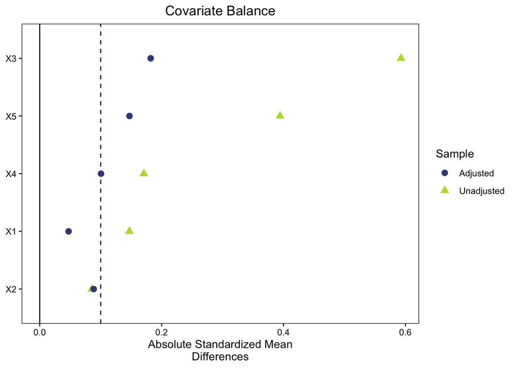

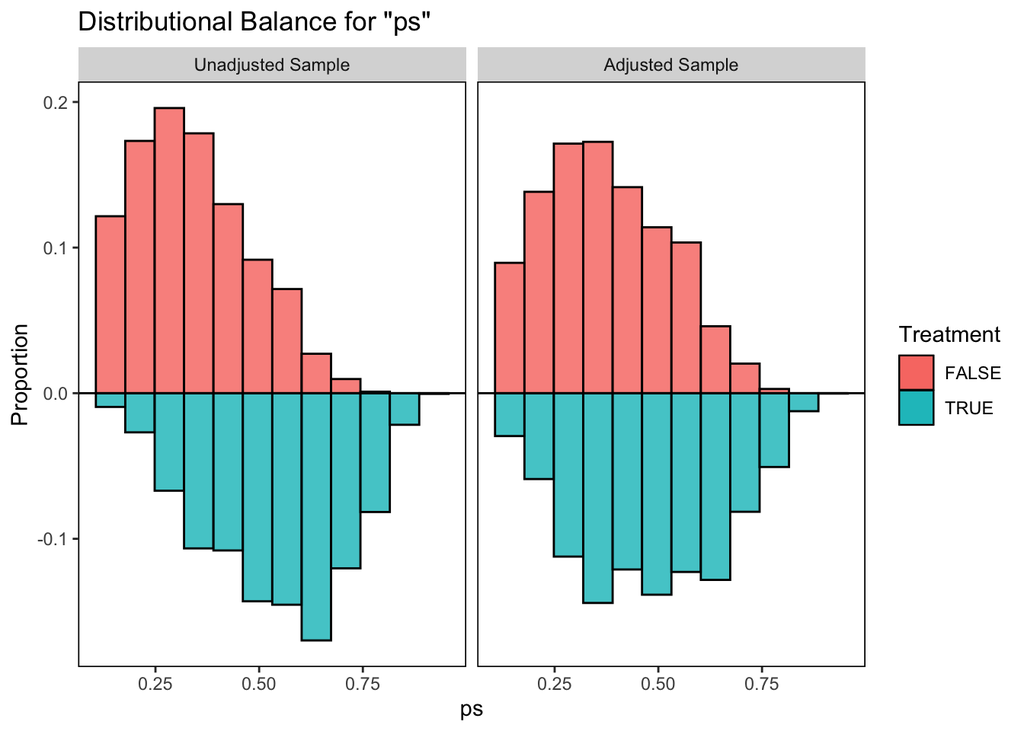

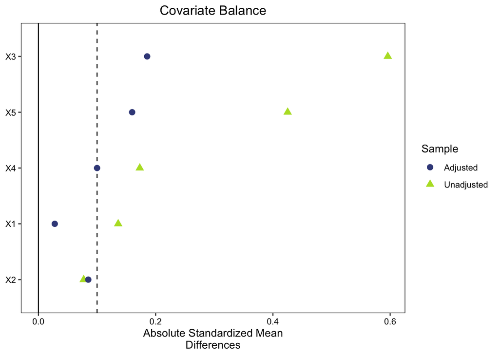

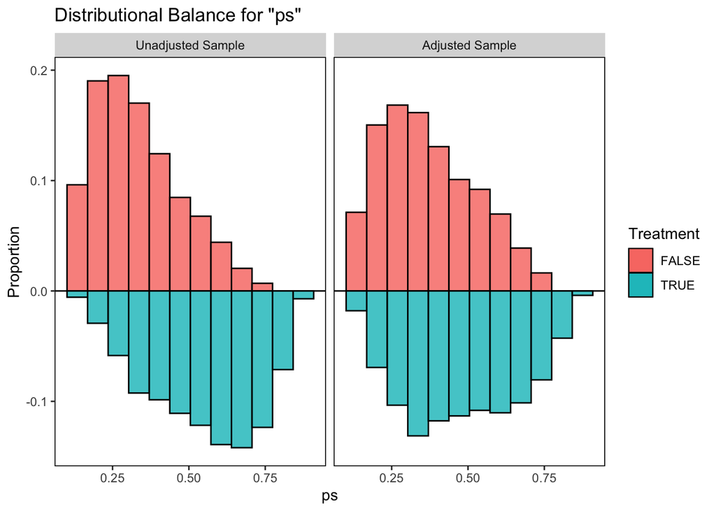

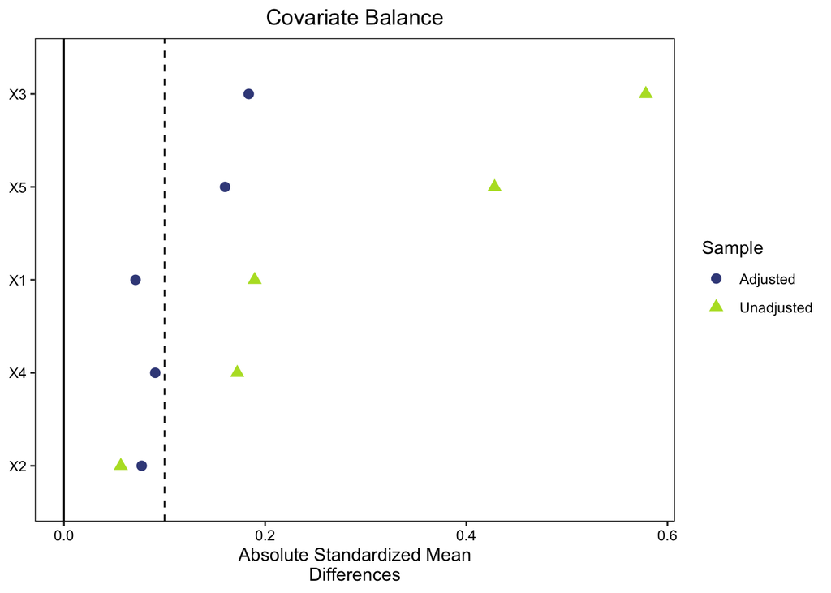

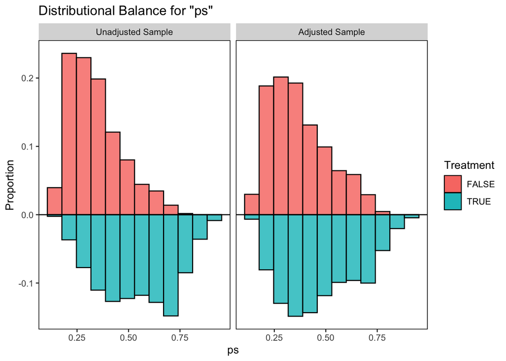

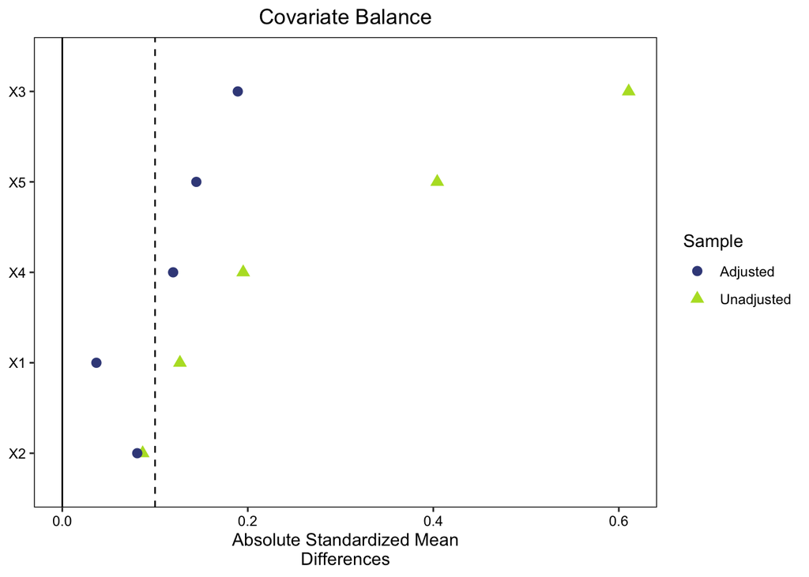

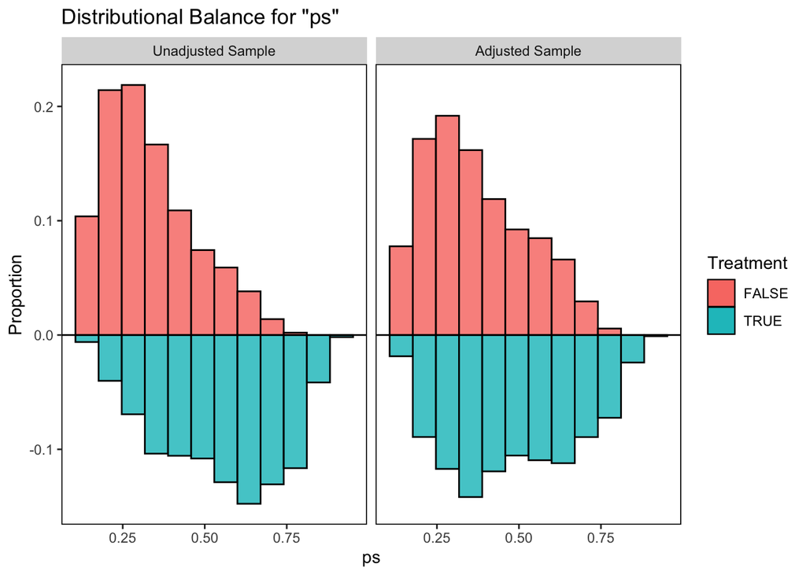

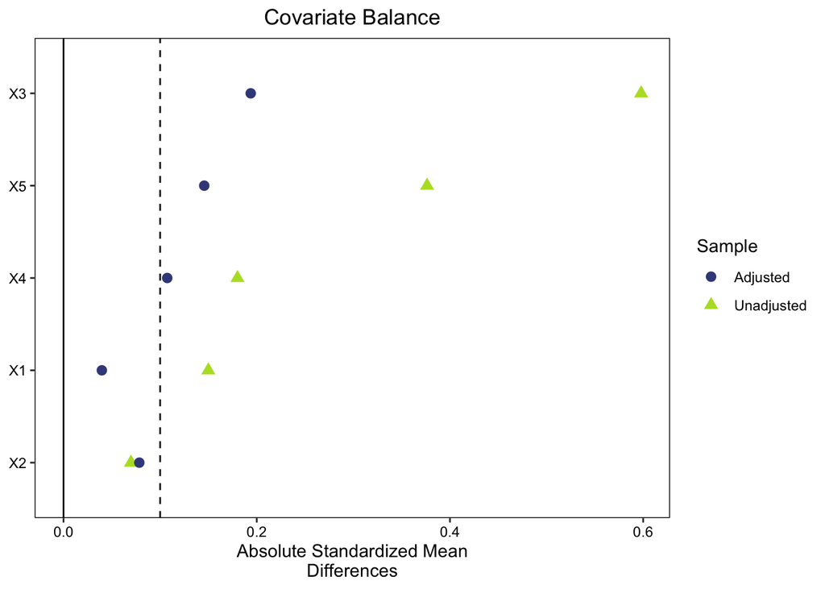

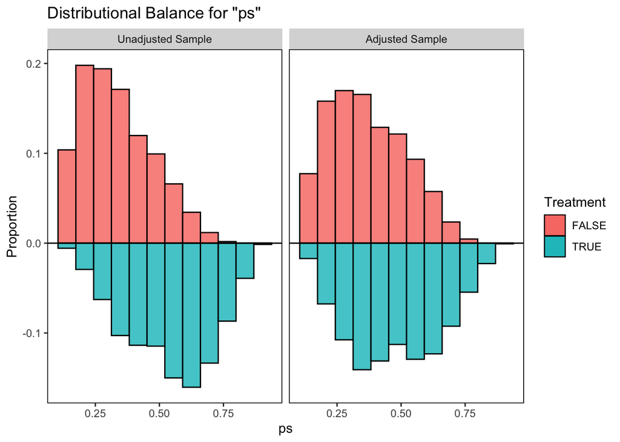

### 6.2.3 On `X.na` using MIA

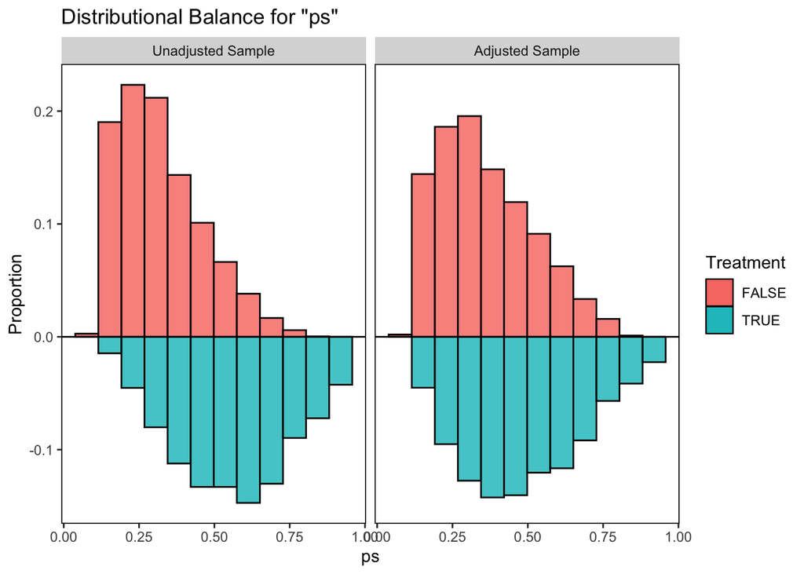

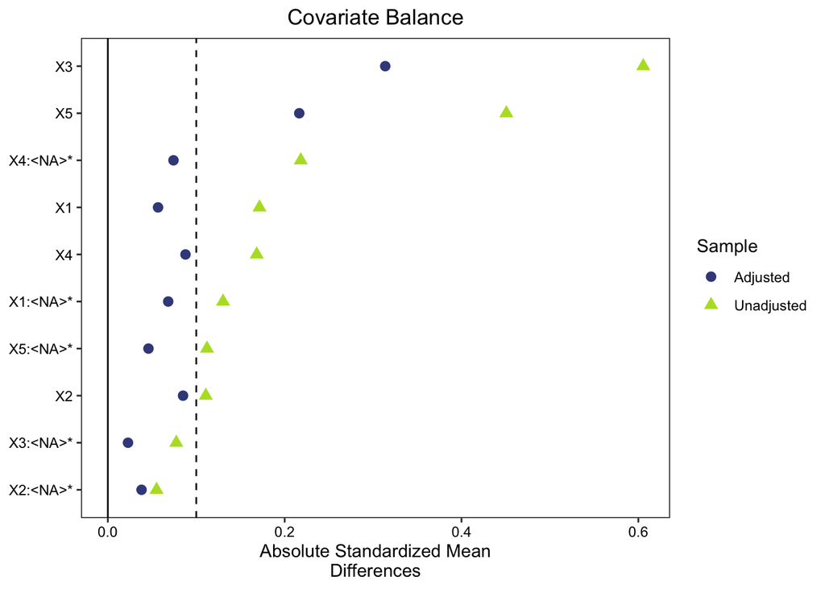

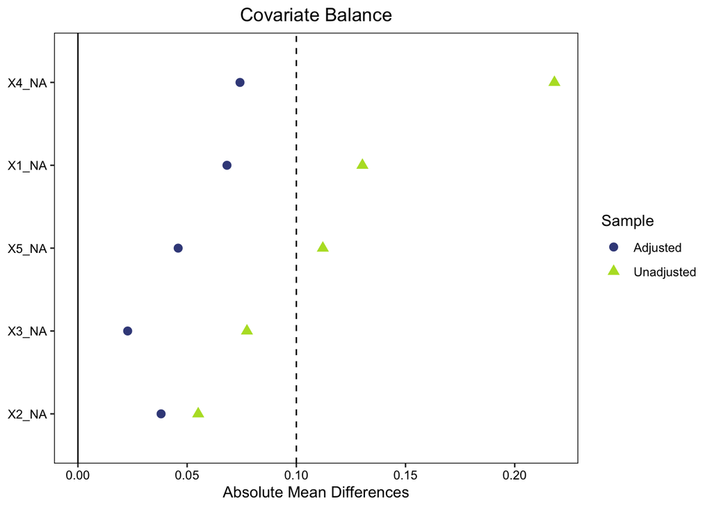

# References

Athey, Susan, Julie Tibshirani, and Stefan Wager. 2019. “Generalized Random Forests.” *Annals of Statistics* 47 (2): 1148–78. https://doi.org/10.1214/18-AOS1709.

Lê, Sébastien, Julie Josse, and François Husson. 2008. “FactoMineR: An R Package for Multivariate Analysis.” *Journal of Statistical Software* 25 (1): 1–18. https://doi.org/10.18637/jss.v025.i01.

Mayer, Imke, Julie Josse, Nicholas Tierney, and Nathalie Vialaneix. 2019. “R-Miss-Tastic: A Unified Platform for Missing Values Methods and Workflows.” *arXiv Preprint*. https://arxiv.org/abs/1908.04822.

Mayer, Imke, Erik Sverdrup, Tobias Gauss, Jean-Denis Moyer, Stefan Wager, and Julie Josse. 2020. “Doubly Robust Treatment Effect Estimation with Missing Attributes.” *Annals of Applied Statistics* 14 (3): 1409–31. https://doi.org/10.1214/20-AOAS1356.

Seaman, Shaun, and Ian White. 2014. “Inverse Probability Weighting with Missing Predictors of Treatment Assignment or Missingness.” *Communications in Statistics - Theory and Methods* 43 (16): 3499–3515. https://doi.org/10.1080/03610926.2012.700371.